# An Analysis on Hostel's in Japan

This dataset is taken from Kaggle.com and contains data on over 300 hostels in Japan. This dataset includes things like which city the hostel's are located in, the price per night, the distance from the city center, and many different ratings. I would like to know things like how much the price varies from place to place and figure out what are possible reasons if there are noticeable differences.

I will be using pandas to tidy the dataset and use numpy, matplotlib, and seaborn to visual the data.

```python
import pandas as pd
```

```python
df = pd.read_csv(r'C:\Users\Brendan Sakihara\Desktop\Coding\Python\Projects\Jovian Project\Hostel.csv')
```

```python
df
```

|  | Unnamed: 0 | hostel.name | City | price.from | Distance | summary.score | rating.band | atmosphere | cleanliness | facilities | location.y | security | staff | valueformoney | lon | lat |
| --- | --- | --- | --- | --- | --- | --- | --- | --- | --- | --- | --- | --- | --- | --- | --- | --- |
| 0 | 1 | "Bike & Bed" CharinCo Hostel | Osaka | 3300 | 2.9km from city centre | 9.2 | Superb | 8.9 | 9.4 | 9.3 | 8.9 | 9.0 | 9.4 | 9.4 | 135.513767 | 34.682678 |
| 1 | 2 | & And Hostel | Fukuoka-City | 2600 | 0.7km from city centre | 9.5 | Superb | 9.4 | 9.7 | 9.5 | 9.7 | 9.2 | 9.7 | 9.5 | NaN | NaN |
| 2 | 3 | &And Hostel Akihabara | Tokyo | 3600 | 7.8km from city centre | 8.7 | Fabulous | 8.0 | 7.0 | 9.0 | 8.0 | 10.0 | 10.0 | 9.0 | 139.777472 | 35.697447 |
| 3 | 4 | &And Hostel Ueno | Tokyo | 2600 | 8.7km from city centre | 7.4 | Very Good | 8.0 | 7.5 | 7.5 | 7.5 | 7.0 | 8.0 | 6.5 | 139.783667 | 35.712716 |
| 4 | 5 | &And Hostel-Asakusa North- | Tokyo | 1500 | 10.5km from city centre | 9.4 | Superb | 9.5 | 9.5 | 9.0 | 9.0 | 9.5 | 10.0 | 9.5 | 139.798371 | 35.727898 |
| ... | ... | ... | ... | ... | ... | ... | ... | ... | ... | ... | ... | ... | ... | ... | ... | ... |
| 337 | 338 | YADOYA Guesthouse Green | Tokyo | 2300 | 2.6km from city centre | 8.2 | Fabulous | 7.9 | 7.7 | 6.9 | 8.9 | 8.9 | 8.8 | 8.3 | 139.668125 | 35.702908 |
| 338 | 339 | YADOYA Guesthouse Orange | Tokyo | 2000 | 2.9km from city centre | 8.9 | Fabulous | 8.6 | 9.0 | 7.8 | 9.4 | 9.0 | 9.2 | 9.4 | 139.667695 | 35.706513 |
| 339 | 340 | YAWP! backpackers | Tokyo | 2500 | 17.5km from city centre | 9.3 | Superb | 9.5 | 9.3 | 9.4 | 8.5 | 9.5 | 9.2 | 9.6 | 139.869197 | 35.752885 |
| 340 | 341 | You En Me House | Kyoto | 2800 | 2.4km from city centre | 8.0 | Fabulous | 7.3 | 8.0 | 6.7 | 8.0 | 8.7 | 10.0 | 7.3 | 135.749063 | 34.997376 |
| 341 | 342 | Zabutton Hostel | Tokyo | 2900 | 5.9km from city centre | 8.6 | Fabulous | 8.1 | 8.5 | 7.8 | 9.0 | 8.9 | 9.5 | 8.5 | 139.742116 | 35.655470 |

342 rows × 16 columns

```python
print(df)
```

```
     Unnamed: 0                   hostel.name          City  price.from  \
0             1  "Bike & Bed" CharinCo Hostel         Osaka        3300
1             2                  & And Hostel  Fukuoka-City        2600
2             3         &And Hostel Akihabara         Tokyo        3600
3             4              &And Hostel Ueno         Tokyo        2600
4             5    &And Hostel-Asakusa North-         Tokyo        1500
..          ...                           ...           ...         ...
337         338       YADOYA Guesthouse Green         Tokyo        2300
338         339      YADOYA Guesthouse Orange         Tokyo        2000
339         340             YAWP! backpackers         Tokyo        2500
340         341               You En Me House         Kyoto        2800
341         342               Zabutton Hostel         Tokyo        2900

                    Distance  summary.score rating.band  atmosphere  \
0     2.9km from city centre            9.2      Superb         8.9
```

[output cut: 38 more lines]

```python
df.info()
```

```
<class 'pandas.core.frame.DataFrame'>
RangeIndex: 342 entries, 0 to 341
Data columns (total 16 columns):
 #   Column         Non-Null Count  Dtype
---  ------         --------------  -----
 0   Unnamed: 0     342 non-null    int64
 1   hostel.name    342 non-null    object
 2   City           342 non-null    object
 3   price.from     342 non-null    int64
 4   Distance       342 non-null    object
 5   summary.score  327 non-null    float64
 6   rating.band    327 non-null    object
 7   atmosphere     327 non-null    float64
 8   cleanliness    327 non-null    float64
 9   facilities     327 non-null    float64
 10  location.y     327 non-null    float64
 11  security       327 non-null    float64
 12  staff          327 non-null    float64
 13  valueformoney  327 non-null    float64
 14  lon            298 non-null    float64
 15  lat            298 non-null    float64
dtypes: float64(10), int64(2), object(4)
memory usage: 42.9+ KB
```

**Key:**  
hostel.name = name of the hostel  
City = the city of the hostel  
price.from = the price per one night stay  
Distance = the distance from the center of the city in km  
summary.score = the average rating based on all the ratings  
rating.band = the rating in word form  
atmosphere = the rating for the atmosphere of the hostel  
cleanliness = the rating for how clean the hostel is  
facilities = the rating of the facilities in the hostel  
location.y = the location rating of the hostel  
security = the rating of the security of the hostel  
staff = the rating of the staff of the hostel  
valueformoney = the rating of the value of the hostel based on the price

```python
df = pd.read_csv(r'C:\Users\Brendan Sakihara\Desktop\Coding\Python\Projects\Jovian Project\Hostel.csv', index_col=0) #re-importing the dataset without the first column
```

```python
df
```

|  | hostel.name | City | price.from | Distance | summary.score | rating.band | atmosphere | cleanliness | facilities | location.y | security | staff | valueformoney | lon | lat |
| --- | --- | --- | --- | --- | --- | --- | --- | --- | --- | --- | --- | --- | --- | --- | --- |
| 1 | "Bike & Bed" CharinCo Hostel | Osaka | 3300 | 2.9km from city centre | 9.2 | Superb | 8.9 | 9.4 | 9.3 | 8.9 | 9.0 | 9.4 | 9.4 | 135.513767 | 34.682678 |
| 2 | & And Hostel | Fukuoka-City | 2600 | 0.7km from city centre | 9.5 | Superb | 9.4 | 9.7 | 9.5 | 9.7 | 9.2 | 9.7 | 9.5 | NaN | NaN |
| 3 | &And Hostel Akihabara | Tokyo | 3600 | 7.8km from city centre | 8.7 | Fabulous | 8.0 | 7.0 | 9.0 | 8.0 | 10.0 | 10.0 | 9.0 | 139.777472 | 35.697447 |
| 4 | &And Hostel Ueno | Tokyo | 2600 | 8.7km from city centre | 7.4 | Very Good | 8.0 | 7.5 | 7.5 | 7.5 | 7.0 | 8.0 | 6.5 | 139.783667 | 35.712716 |
| 5 | &And Hostel-Asakusa North- | Tokyo | 1500 | 10.5km from city centre | 9.4 | Superb | 9.5 | 9.5 | 9.0 | 9.0 | 9.5 | 10.0 | 9.5 | 139.798371 | 35.727898 |
| ... | ... | ... | ... | ... | ... | ... | ... | ... | ... | ... | ... | ... | ... | ... | ... |
| 338 | YADOYA Guesthouse Green | Tokyo | 2300 | 2.6km from city centre | 8.2 | Fabulous | 7.9 | 7.7 | 6.9 | 8.9 | 8.9 | 8.8 | 8.3 | 139.668125 | 35.702908 |
| 339 | YADOYA Guesthouse Orange | Tokyo | 2000 | 2.9km from city centre | 8.9 | Fabulous | 8.6 | 9.0 | 7.8 | 9.4 | 9.0 | 9.2 | 9.4 | 139.667695 | 35.706513 |
| 340 | YAWP! backpackers | Tokyo | 2500 | 17.5km from city centre | 9.3 | Superb | 9.5 | 9.3 | 9.4 | 8.5 | 9.5 | 9.2 | 9.6 | 139.869197 | 35.752885 |
| 341 | You En Me House | Kyoto | 2800 | 2.4km from city centre | 8.0 | Fabulous | 7.3 | 8.0 | 6.7 | 8.0 | 8.7 | 10.0 | 7.3 | 135.749063 | 34.997376 |
| 342 | Zabutton Hostel | Tokyo | 2900 | 5.9km from city centre | 8.6 | Fabulous | 8.1 | 8.5 | 7.8 | 9.0 | 8.9 | 9.5 | 8.5 | 139.742116 | 35.655470 |

342 rows × 15 columns

I won't be using the longitude and latitude information so I will drop it from the dataset.

```python
df_edit = df.copy() #making copies in case I need to go back
```

```python
df_nolatlong = df_edit.drop(['lon','lat'], axis = 1)
df_nolatlong
```

|  | hostel.name | City | price.from | Distance | summary.score | rating.band | atmosphere | cleanliness | facilities | location.y | security | staff | valueformoney |
| --- | --- | --- | --- | --- | --- | --- | --- | --- | --- | --- | --- | --- | --- |
| 1 | "Bike & Bed" CharinCo Hostel | Osaka | 3300 | 2.9km from city centre | 9.2 | Superb | 8.9 | 9.4 | 9.3 | 8.9 | 9.0 | 9.4 | 9.4 |
| 2 | & And Hostel | Fukuoka-City | 2600 | 0.7km from city centre | 9.5 | Superb | 9.4 | 9.7 | 9.5 | 9.7 | 9.2 | 9.7 | 9.5 |
| 3 | &And Hostel Akihabara | Tokyo | 3600 | 7.8km from city centre | 8.7 | Fabulous | 8.0 | 7.0 | 9.0 | 8.0 | 10.0 | 10.0 | 9.0 |
| 4 | &And Hostel Ueno | Tokyo | 2600 | 8.7km from city centre | 7.4 | Very Good | 8.0 | 7.5 | 7.5 | 7.5 | 7.0 | 8.0 | 6.5 |
| 5 | &And Hostel-Asakusa North- | Tokyo | 1500 | 10.5km from city centre | 9.4 | Superb | 9.5 | 9.5 | 9.0 | 9.0 | 9.5 | 10.0 | 9.5 |
| ... | ... | ... | ... | ... | ... | ... | ... | ... | ... | ... | ... | ... | ... |
| 338 | YADOYA Guesthouse Green | Tokyo | 2300 | 2.6km from city centre | 8.2 | Fabulous | 7.9 | 7.7 | 6.9 | 8.9 | 8.9 | 8.8 | 8.3 |
| 339 | YADOYA Guesthouse Orange | Tokyo | 2000 | 2.9km from city centre | 8.9 | Fabulous | 8.6 | 9.0 | 7.8 | 9.4 | 9.0 | 9.2 | 9.4 |
| 340 | YAWP! backpackers | Tokyo | 2500 | 17.5km from city centre | 9.3 | Superb | 9.5 | 9.3 | 9.4 | 8.5 | 9.5 | 9.2 | 9.6 |
| 341 | You En Me House | Kyoto | 2800 | 2.4km from city centre | 8.0 | Fabulous | 7.3 | 8.0 | 6.7 | 8.0 | 8.7 | 10.0 | 7.3 |
| 342 | Zabutton Hostel | Tokyo | 2900 | 5.9km from city centre | 8.6 | Fabulous | 8.1 | 8.5 | 7.8 | 9.0 | 8.9 | 9.5 | 8.5 |

342 rows × 13 columns

Some hostel's had values that included NA so I decided to drop them as well.

```python
df_clean = df_nolatlong.copy()
```

```python
df_clean = df_clean.dropna()
```

I also noticed that in distance, it has 'km from city centre' after the number so I want to get rid of that so that they are just numbers using the str.replace method.

```python
df_clean["Distance"] = df_clean["Distance"].str.replace('km from city centre', '')
```

Since distance is still an object due it having the text previously, I will convert it into a float.

```python
df_clean["Distance"] = df_clean.Distance.astype(float)
```

```python
df_clean.info()
```

```
<class 'pandas.core.frame.DataFrame'>
Int64Index: 327 entries, 1 to 342
Data columns (total 13 columns):
 #   Column         Non-Null Count  Dtype
---  ------         --------------  -----
 0   hostel.name    327 non-null    object
 1   City           327 non-null    object
 2   price.from     327 non-null    int64
 3   Distance       327 non-null    float64
 4   summary.score  327 non-null    float64
 5   rating.band    327 non-null    object
 6   atmosphere     327 non-null    float64
 7   cleanliness    327 non-null    float64
 8   facilities     327 non-null    float64
 9   location.y     327 non-null    float64
 10  security       327 non-null    float64
 11  staff          327 non-null    float64
 12  valueformoney  327 non-null    float64
dtypes: float64(9), int64(1), object(3)
memory usage: 35.8+ KB
```

I want to rename some of the columns to a more simpler name using the rename method.

```python
df_clean = df_clean.rename(columns={'hostel.name': 'hostel', 'City': 'city', 'price.from': 'price', 'Distance': 'distance', 'summary.score': 'summary', 'rating.band': 'rating', 'location.y': 'location_rating', 'valueformoney': 'value'})
```

```python
df_clean
```

|  | hostel | city | price | distance | summary | rating | atmosphere | cleanliness | facilities | location_rating | security | staff | value |
| --- | --- | --- | --- | --- | --- | --- | --- | --- | --- | --- | --- | --- | --- |
| 1 | "Bike & Bed" CharinCo Hostel | Osaka | 3300 | 2.9 | 9.2 | Superb | 8.9 | 9.4 | 9.3 | 8.9 | 9.0 | 9.4 | 9.4 |
| 2 | & And Hostel | Fukuoka-City | 2600 | 0.7 | 9.5 | Superb | 9.4 | 9.7 | 9.5 | 9.7 | 9.2 | 9.7 | 9.5 |
| 3 | &And Hostel Akihabara | Tokyo | 3600 | 7.8 | 8.7 | Fabulous | 8.0 | 7.0 | 9.0 | 8.0 | 10.0 | 10.0 | 9.0 |
| 4 | &And Hostel Ueno | Tokyo | 2600 | 8.7 | 7.4 | Very Good | 8.0 | 7.5 | 7.5 | 7.5 | 7.0 | 8.0 | 6.5 |
| 5 | &And Hostel-Asakusa North- | Tokyo | 1500 | 10.5 | 9.4 | Superb | 9.5 | 9.5 | 9.0 | 9.0 | 9.5 | 10.0 | 9.5 |
| ... | ... | ... | ... | ... | ... | ... | ... | ... | ... | ... | ... | ... | ... |
| 338 | YADOYA Guesthouse Green | Tokyo | 2300 | 2.6 | 8.2 | Fabulous | 7.9 | 7.7 | 6.9 | 8.9 | 8.9 | 8.8 | 8.3 |
| 339 | YADOYA Guesthouse Orange | Tokyo | 2000 | 2.9 | 8.9 | Fabulous | 8.6 | 9.0 | 7.8 | 9.4 | 9.0 | 9.2 | 9.4 |
| 340 | YAWP! backpackers | Tokyo | 2500 | 17.5 | 9.3 | Superb | 9.5 | 9.3 | 9.4 | 8.5 | 9.5 | 9.2 | 9.6 |
| 341 | You En Me House | Kyoto | 2800 | 2.4 | 8.0 | Fabulous | 7.3 | 8.0 | 6.7 | 8.0 | 8.7 | 10.0 | 7.3 |
| 342 | Zabutton Hostel | Tokyo | 2900 | 5.9 | 8.6 | Fabulous | 8.1 | 8.5 | 7.8 | 9.0 | 8.9 | 9.5 | 8.5 |

327 rows × 13 columns

I noticed later on that Fukuoka was the only city that has '-City' at the end of it so I want to get rid of that for consistency using the str.replace method.

```python
df_clean["city"] = df_clean["city"].str.replace('-City', '')
```

```python
df_clean
```

|  | hostel | city | price | distance | summary | rating | atmosphere | cleanliness | facilities | location_rating | security | staff | value |
| --- | --- | --- | --- | --- | --- | --- | --- | --- | --- | --- | --- | --- | --- |
| 1 | "Bike & Bed" CharinCo Hostel | Osaka | 3300 | 2.9 | 9.2 | Superb | 8.9 | 9.4 | 9.3 | 8.9 | 9.0 | 9.4 | 9.4 |
| 2 | & And Hostel | Fukuoka | 2600 | 0.7 | 9.5 | Superb | 9.4 | 9.7 | 9.5 | 9.7 | 9.2 | 9.7 | 9.5 |
| 3 | &And Hostel Akihabara | Tokyo | 3600 | 7.8 | 8.7 | Fabulous | 8.0 | 7.0 | 9.0 | 8.0 | 10.0 | 10.0 | 9.0 |
| 4 | &And Hostel Ueno | Tokyo | 2600 | 8.7 | 7.4 | Very Good | 8.0 | 7.5 | 7.5 | 7.5 | 7.0 | 8.0 | 6.5 |
| 5 | &And Hostel-Asakusa North- | Tokyo | 1500 | 10.5 | 9.4 | Superb | 9.5 | 9.5 | 9.0 | 9.0 | 9.5 | 10.0 | 9.5 |
| ... | ... | ... | ... | ... | ... | ... | ... | ... | ... | ... | ... | ... | ... |
| 338 | YADOYA Guesthouse Green | Tokyo | 2300 | 2.6 | 8.2 | Fabulous | 7.9 | 7.7 | 6.9 | 8.9 | 8.9 | 8.8 | 8.3 |
| 339 | YADOYA Guesthouse Orange | Tokyo | 2000 | 2.9 | 8.9 | Fabulous | 8.6 | 9.0 | 7.8 | 9.4 | 9.0 | 9.2 | 9.4 |
| 340 | YAWP! backpackers | Tokyo | 2500 | 17.5 | 9.3 | Superb | 9.5 | 9.3 | 9.4 | 8.5 | 9.5 | 9.2 | 9.6 |
| 341 | You En Me House | Kyoto | 2800 | 2.4 | 8.0 | Fabulous | 7.3 | 8.0 | 6.7 | 8.0 | 8.7 | 10.0 | 7.3 |
| 342 | Zabutton Hostel | Tokyo | 2900 | 5.9 | 8.6 | Fabulous | 8.1 | 8.5 | 7.8 | 9.0 | 8.9 | 9.5 | 8.5 |

327 rows × 13 columns

## Exploratory Analysis and Visualization

After cleaning up the dataset, there are still many things in the data that we don't know about. Since Japan is somewhere many people want to go for a vacation one day (after they open up again due to COVID-19 of course), I mainly wanted to see things based on location like prices based on location or ratings for example.

```python
import seaborn as sns
import matplotlib
import matplotlib.pyplot as plt
%matplotlib inline

sns.set_style('darkgrid')
matplotlib.rcParams['font.size'] = 14
matplotlib.rcParams['figure.figsize'] = (9, 5)
matplotlib.rcParams['figure.facecolor'] = '#00000000'
```

**Seeing how many hostel's were counted for in each city**

```python
df_clean['city'].value_counts()
```

```
Tokyo        122
Osaka        101
Kyoto         73
Fukuoka       17
Hiroshima     14
Name: city, dtype: int64
```

I first wanted to see how many hostel's were counted for in each city.

We first see that the cities that the hostel's are located in are Tokyo, Osaka, Kyoto, Fukuoka, and Hiroshima.

It is no surprised that Tokyo and Osaka have the most hostels listed as they are the two most popular cities in Japan and are where most of the tourists go to. The order more or less goes from most popular to least popular cities for tourists.

**Exploring the relationship of the price of the hostels based on the distance away from the center of the city**

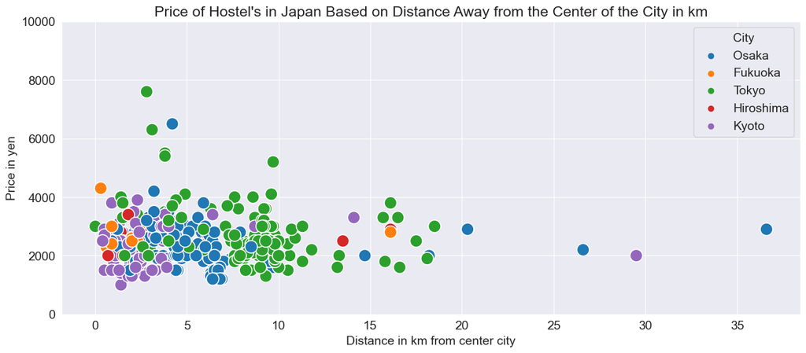

```python
plt.figure(figsize=(15, 6))
plt.title("Price of Hostel's in Japan Based on Distance Away from the Center of the City in km")
g = sns.scatterplot(x=df_clean.distance, y=df_clean.price, hue=df_clean.city, s=200);
g.set(ylim = (0,10000));
g.set(xlabel = 'Distance in km from center city', ylabel = 'Price in yen');
plt.legend(title='City');
```

I plotted this graph using seaborn's scatterplot method and using matplotlib to label and organize everything.

This graph shows the prices of all the hostel's based on their distance from the center of the city for each city. We see that the majority of the points are all clumped up together around the 1500 yen to 4000 yen area and are mainly within 0 to 10 km of the center of the city. Interestingly enough, there isn't much of a variation in price based on distance so there must be other factors into how the hostel's are priced.

**Exploring the ratings of the hostel**

```python
df_clean['rating'].value_counts()
```

```
Superb       182
Fabulous     106
Very Good     20
Good          11
Rating         8
Name: rating, dtype: int64
```

I used the value_counts method to return the count of each rating.

As we can see, the majority of the hostel's in the dataset have a rating of superb or fabulous. Those two ratings make up around 88% of the total ratings. Japan is known for being clean and having great service so it does not really surprise me seeing the majority of the ratings be at the top. I am not sure what the 'rating' rating is but it makes up only about 2% of the total ratings.

I am now curious about what its like in each city now.

```python
df_clean.groupby('city')['rating'].value_counts()
```

```
city       rating
Fukuoka    Superb        9
           Fabulous      8
Hiroshima  Superb       11
           Fabulous      3
Kyoto      Superb       46
           Fabulous     21
           Good          2
           Rating        2
           Very Good     2
Osaka      Superb       50
           Fabulous     35
           Good          7
           Very Good     6
           Rating        3
Tokyo      Superb       66
           Fabulous     39
           Very Good    12
           Rating        3
           Good          2
Name: rating, dtype: int64
```

Although there was a small sample size for Fukuoka and Hiroshima hostel's, all of them were rated in either superb or fabulous.

Around 86% of the hostel's in Tokyo are rated superb or fabulous. 84% for Osaka, and 92% for Kyoto.

**Exploring if there is a relationship of the location rating and the distance the hostel is from the center of the city**

```python
import numpy as np
```

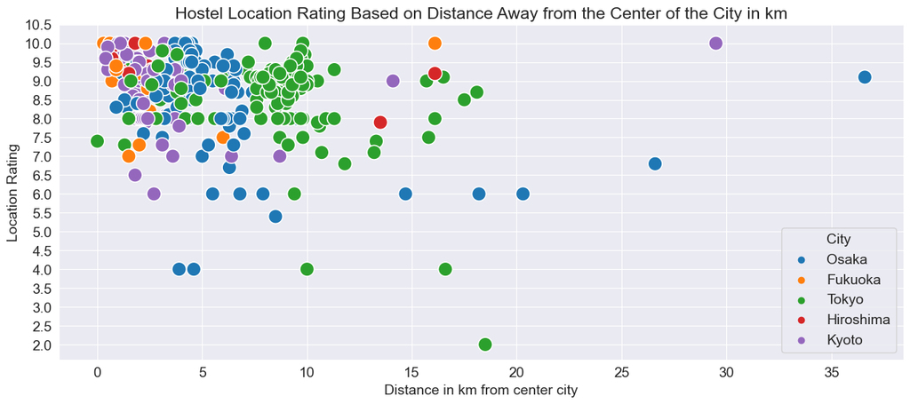

```python
plt.figure(figsize=(15, 6))
plt.title("Hostel Location Rating Based on Distance Away from the Center of the City in km")
g = sns.scatterplot(x=df_clean.distance, y=df_clean.location_rating, hue=df_clean.city, s=200);
plt.yticks(np.arange(min(df_clean.location_rating), max(df_clean.location_rating)+1, 0.5))
g.set(xlabel = 'Distance in km from center city', ylabel = 'Location Rating');
plt.legend(title='City');
```

I used seaborn once again to create a scatter plot of the data and used matplotlib as well as numpy this time to label and organize everything.

I wanted to see if there was some kind of correlation based on the location rating and the distance from the center of the city. Though there isn't any correlation, as I expected, the closer the hostel is located from the center of the city, the higher rating it is. Similarly with the first scatter plot between the price of hostel's in Japan based on distance away from the center of the city, there most of the hostels are highly rated when the hostel is located between 0 to 10 km from the center of the city.

**Exploring the averages of the other ratings**

```python
df_clean.groupby(['city'])[['atmosphere','cleanliness','facilities','security','staff','value']].mean()
```

| city | atmosphere | cleanliness | facilities | security | staff | value |
| --- | --- | --- | --- | --- | --- | --- |
| Fukuoka | 8.817647 | 9.376471 | 8.900000 | 9.076471 | 9.358824 | 8.982353 |
| Hiroshima | 8.535714 | 9.535714 | 8.785714 | 9.371429 | 9.450000 | 9.242857 |
| Kyoto | 8.441096 | 9.345205 | 8.793151 | 9.094521 | 9.168493 | 9.013699 |
| Osaka | 8.091089 | 8.754455 | 8.501980 | 8.697030 | 9.064356 | 8.700000 |
| Tokyo | 8.125410 | 8.914754 | 8.495902 | 9.000000 | 9.101639 | 8.808197 |

I wanted to see the average ratings of all the other ratings that were in the dataset. From looking at all the averages, we see that all the ratings for every category are very close city to city at around 8.0 to mid 9.0. This leads me to believe that Japan holds a high importance on the overall well-being for the visitors to ensure that their stay is as best as possible.

## Asking and Answering Questions

There are still some unanswered question I have so I will be exploring more on the dataset and taking a more in-depth look into it.

#### Q1: What is the average price of the Hostel's in each city?

```python
avg_price_city_df = df_clean.groupby('city')[['price']].mean()
avg_price_city_df
```

| city | price |
| --- | --- |
| Fukuoka | 2658.823529 |
| Hiroshima | 2578.571429 |
| Kyoto | 2238.356164 |
| Osaka | 12289.108911 |
| Tokyo | 10904.918033 |

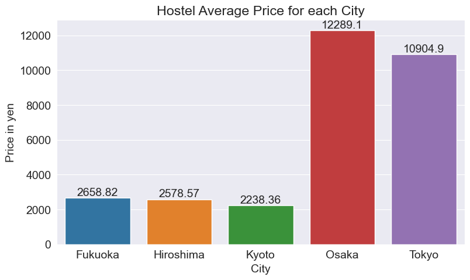

```python
bar0 = sns.barplot(x = avg_price_city_df.index, y = avg_price_city_df.price);
plt.title('Hostel Average Price for each City');
plt.xlabel('City');
plt.ylabel('Price in yen');
bar0.bar_label(bar0.containers[0]);
```

When looking at the scatter plot of all the prices of the hostel across Japan, I assumed that the average prices would be relatively close to each other. Surprisingly we see that Osaka and Tokyo have a much higher average price at around 10000 to 12000 yen (around 100 to 120 usd) while Fukuoka, Hiroshima, Kyoto are relatively close to each other at around 2000 to 3000 yen (around 20 to 30 usd).

This seemed strange based on the information from the scatter plot so I looked into the dataset more in-depth.

```python
df_clean.groupby(['city'])[['price']].describe()
```

| city | price count | price mean | price std | price min | price 25% | price 50% | price 75% | price max |
| --- | --- | --- | --- | --- | --- | --- | --- | --- |
| Fukuoka | 17.0 | 2658.823529 | 469.119952 | 2300.0 | 2500.0 | 2500.0 | 2600.0 | 4300.0 |
| Hiroshima | 14.0 | 2578.571429 | 428.195806 | 2000.0 | 2300.0 | 2550.0 | 2900.0 | 3400.0 |
| Kyoto | 73.0 | 2238.356164 | 682.444572 | 1000.0 | 1600.0 | 2200.0 | 2700.0 | 3900.0 |
| Osaka | 101.0 | 12289.108911 | 99588.049384 | 1200.0 | 2000.0 | 2300.0 | 2800.0 | 1003200.0 |
| Tokyo | 122.0 | 10904.918033 | 90585.744826 | 1300.0 | 2100.0 | 2500.0 | 3150.0 | 1003200.0 |

Using the describe method, I checked the summary statistics of all the prices in each city and saw that Osaka and Tokyo have a much higher max than the other cities at 1003200 yen (around 10,000 usd).

```python
df_clean.groupby(['city'])[['price']].idxmax()
```

| city | price |
| --- | --- |
| Fukuoka | 41 |
| Hiroshima | 223 |
| Kyoto | 239 |
| Osaka | 290 |
| Tokyo | 317 |

```python
df_clean.loc[([41, 223, 239, 290, 317])]
```

|  | hostel | city | price | distance | summary | rating | atmosphere | cleanliness | facilities | location_rating | security | staff | value |
| --- | --- | --- | --- | --- | --- | --- | --- | --- | --- | --- | --- | --- | --- |
| 41 | Book And Bed Tokyo Fukuoka | Fukuoka | 4300 | 0.3 | 8.6 | Fabulous | 8.0 | 10.0 | 6.0 | 10.0 | 8.0 | 10.0 | 8.0 |
| 223 | Kyoubashi Ryokan | Hiroshima | 3400 | 1.8 | 8.6 | Fabulous | 6.0 | 10.0 | 6.0 | 10.0 | 10.0 | 8.0 | 10.0 |
| 239 | O-yado Sato | Kyoto | 3900 | 2.3 | 9.1 | Superb | 9.0 | 10.0 | 9.0 | 8.0 | 10.0 | 9.0 | 9.0 |
| 290 | Shell Nell namba | Osaka | 1003200 | 4.8 | 8.3 | Fabulous | 6.0 | 8.0 | 9.0 | 9.0 | 9.0 | 9.0 | 8.0 |
| 317 | Tokyo Central Youth Hostel | Tokyo | 1003200 | 4.8 | 8.0 | Fabulous | 6.0 | 10.0 | 10.0 | 8.0 | 8.0 | 8.0 | 6.0 |

Using the idxmax and loc method, I found the index for the highest prices for each city.

Since the hostel in Osaka and Tokyo are clear outliers, I want to compare the average prices of the hostels in each city again but excluding these two hostels.

```python
df_no_out = df_clean.copy()
```

```python
df_no_out = df_no_out.drop([290, 317])
df_no_out
```

|  | hostel | city | price | distance | summary | rating | atmosphere | cleanliness | facilities | location_rating | security | staff | value |
| --- | --- | --- | --- | --- | --- | --- | --- | --- | --- | --- | --- | --- | --- |
| 1 | "Bike & Bed" CharinCo Hostel | Osaka | 3300 | 2.9 | 9.2 | Superb | 8.9 | 9.4 | 9.3 | 8.9 | 9.0 | 9.4 | 9.4 |
| 2 | & And Hostel | Fukuoka | 2600 | 0.7 | 9.5 | Superb | 9.4 | 9.7 | 9.5 | 9.7 | 9.2 | 9.7 | 9.5 |
| 3 | &And Hostel Akihabara | Tokyo | 3600 | 7.8 | 8.7 | Fabulous | 8.0 | 7.0 | 9.0 | 8.0 | 10.0 | 10.0 | 9.0 |
| 4 | &And Hostel Ueno | Tokyo | 2600 | 8.7 | 7.4 | Very Good | 8.0 | 7.5 | 7.5 | 7.5 | 7.0 | 8.0 | 6.5 |
| 5 | &And Hostel-Asakusa North- | Tokyo | 1500 | 10.5 | 9.4 | Superb | 9.5 | 9.5 | 9.0 | 9.0 | 9.5 | 10.0 | 9.5 |
| ... | ... | ... | ... | ... | ... | ... | ... | ... | ... | ... | ... | ... | ... |
| 338 | YADOYA Guesthouse Green | Tokyo | 2300 | 2.6 | 8.2 | Fabulous | 7.9 | 7.7 | 6.9 | 8.9 | 8.9 | 8.8 | 8.3 |
| 339 | YADOYA Guesthouse Orange | Tokyo | 2000 | 2.9 | 8.9 | Fabulous | 8.6 | 9.0 | 7.8 | 9.4 | 9.0 | 9.2 | 9.4 |
| 340 | YAWP! backpackers | Tokyo | 2500 | 17.5 | 9.3 | Superb | 9.5 | 9.3 | 9.4 | 8.5 | 9.5 | 9.2 | 9.6 |
| 341 | You En Me House | Kyoto | 2800 | 2.4 | 8.0 | Fabulous | 7.3 | 8.0 | 6.7 | 8.0 | 8.7 | 10.0 | 7.3 |
| 342 | Zabutton Hostel | Tokyo | 2900 | 5.9 | 8.6 | Fabulous | 8.1 | 8.5 | 7.8 | 9.0 | 8.9 | 9.5 | 8.5 |

325 rows × 13 columns

I was able to get rid of the two outlier's using the drop method.

```python
df_no_out.groupby(['city'])[['price']].describe()
```

| city | price count | price mean | price std | price min | price 25% | price 50% | price 75% | price max |
| --- | --- | --- | --- | --- | --- | --- | --- | --- |
| Fukuoka | 17.0 | 2658.823529 | 469.119952 | 2300.0 | 2500.0 | 2500.0 | 2600.0 | 4300.0 |
| Hiroshima | 14.0 | 2578.571429 | 428.195806 | 2000.0 | 2300.0 | 2550.0 | 2900.0 | 3400.0 |
| Kyoto | 73.0 | 2238.356164 | 682.444572 | 1000.0 | 1600.0 | 2200.0 | 2700.0 | 3900.0 |
| Osaka | 100.0 | 2380.000000 | 742.096403 | 1200.0 | 2000.0 | 2300.0 | 2800.0 | 6500.0 |
| Tokyo | 121.0 | 2704.132231 | 965.694629 | 1300.0 | 2100.0 | 2500.0 | 3000.0 | 7600.0 |

```python
avg_price_city_no_out_df = df_no_out.groupby('city')[['price']].mean()
avg_price_city_no_out_df
```

| city | price |
| --- | --- |
| Fukuoka | 2658.823529 |
| Hiroshima | 2578.571429 |
| Kyoto | 2238.356164 |
| Osaka | 2380.000000 |
| Tokyo | 2704.132231 |

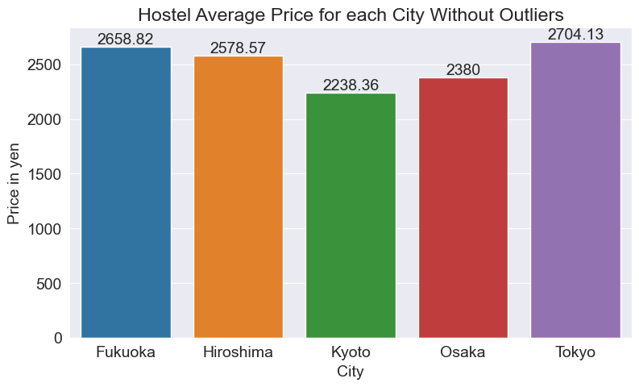

```python
bar1 = sns.barplot(x = avg_price_city_no_out_df.index, y = avg_price_city_no_out_df.price);
plt.title('Hostel Average Price for each City Without Outliers');
plt.xlabel('City');
plt.ylabel('Price in yen');
bar1.bar_label(bar1.containers[0]);
```

Without the outliers, we now see that the average prices are more even with each other at around 2200 to 2700 yen which is overall quite cheap (low 20 usd). Now we can see that Tokyo and Fukuoka have the highest average price but only by few hundred yen (which are about a few usd).

#### Q2: What kind of scores did the hostel with the 'rating' rating have?

The 'rating' rating was something I didn't know what it meant so I wanted to see if the scores of the other variables can give us a possible reason as to why these hostel have that weird rating.

As we found out previously, Fukuoka and Hiroshima had only superb or fabulous ratings so that would mean the hostel's that got the 'rating' rating are in Tokyo, Osaka, and Kyoto.

```python
df_clean.loc[df_clean['rating'] == 'Rating']
```

|  | hostel | city | price | distance | summary | rating | atmosphere | cleanliness | facilities | location_rating | security | staff | value |
| --- | --- | --- | --- | --- | --- | --- | --- | --- | --- | --- | --- | --- | --- |
| 35 | bnb+ Ninja Dojo Ueno | Tokyo | 2500 | 8.0 | 5.2 | Rating | 4.0 | 3.3 | 4.0 | 8.7 | 5.3 | 4.7 | 6.7 |
| 36 | bnb+Shinjuku Castle | Tokyo | 2500 | 1.3 | 5.0 | Rating | 2.7 | 4.0 | 3.3 | 7.3 | 5.3 | 5.3 | 6.7 |
| 68 | Ezstay Osaka | Osaka | 2000 | 4.6 | 3.1 | Rating | 2.0 | 2.0 | 2.0 | 4.0 | 6.0 | 2.0 | 4.0 |
| 141 | Hostel Ginkakuji | Kyoto | 1300 | 2.7 | 4.9 | Rating | 2.0 | 10.0 | 6.0 | 6.0 | 2.0 | 2.0 | 6.0 |
| 235 | Nagomi-Ryokan Yuu | Kyoto | 3100 | 2.2 | 5.1 | Rating | 6.0 | 6.0 | 2.0 | 8.0 | 6.0 | 2.0 | 6.0 |
| 273 | Qoo Ebisucho | Osaka | 2000 | 5.5 | 5.7 | Rating | 6.0 | 8.0 | 6.0 | 6.0 | 2.0 | 8.0 | 4.0 |
| 281 | Sakura Guest House | Osaka | 2700 | 4.3 | 4.9 | Rating | 4.0 | 4.0 | 4.0 | 8.0 | 4.0 | 6.0 | 4.0 |
| 291 | Shibamata FU-TEN Bed and Local | Tokyo | 3000 | 18.5 | 4.9 | Rating | 2.0 | 4.0 | 2.0 | 2.0 | 10.0 | 10.0 | 4.0 |

Using the loc method, I was able to see the hostel's that had the 'rating' rating.

We can see that there are 3 hostel's in Tokyo, 3 hostel's in Osaka, and 2 hostel's in Kyoto that have the 'rating' rating.

Looking at the other scores, we can see that there are few scores that are very low (lower that 5.0) for every hostel. We can even see some 2.0 ratings which is a very bad rating.

I want to see the scores of hostel's with the superb rating to see if there are any low scores.

```python
df_clean.loc[df_clean['rating'] == 'Superb']
```

|  | hostel | city | price | distance | summary | rating | atmosphere | cleanliness | facilities | location_rating | security | staff | value |
| --- | --- | --- | --- | --- | --- | --- | --- | --- | --- | --- | --- | --- | --- |
| 1 | "Bike & Bed" CharinCo Hostel | Osaka | 3300 | 2.9 | 9.2 | Superb | 8.9 | 9.4 | 9.3 | 8.9 | 9.0 | 9.4 | 9.4 |
| 2 | & And Hostel | Fukuoka | 2600 | 0.7 | 9.5 | Superb | 9.4 | 9.7 | 9.5 | 9.7 | 9.2 | 9.7 | 9.5 |
| 5 | &And Hostel-Asakusa North- | Tokyo | 1500 | 10.5 | 9.4 | Superb | 9.5 | 9.5 | 9.0 | 9.0 | 9.5 | 10.0 | 9.5 |
| 7 | 328 Hostel & Lounge | Tokyo | 3300 | 16.5 | 9.3 | Superb | 8.7 | 9.7 | 9.3 | 9.1 | 9.3 | 9.7 | 8.9 |
| 8 | 36Hostel | Hiroshima | 2000 | 1.6 | 9.5 | Superb | 8.8 | 9.9 | 9.2 | 9.6 | 9.8 | 9.8 | 9.5 |
| ... | ... | ... | ... | ... | ... | ... | ... | ... | ... | ... | ... | ... | ... |
| 333 | WIRED HOTEL Asakusa | Tokyo | 5200 | 9.7 | 9.5 | Superb | 8.9 | 10.0 | 9.9 | 9.1 | 9.7 | 9.6 | 9.5 |
| 334 | Wise Owl Hostels Shibuya | Tokyo | 2500 | 4.0 | 9.1 | Superb | 8.9 | 9.6 | 9.1 | 8.4 | 9.6 | 9.5 | 8.8 |
| 335 | Wise Owl Hostels Tokyo | Tokyo | 2000 | 7.9 | 9.1 | Superb | 8.4 | 9.5 | 9.1 | 9.1 | 9.4 | 9.3 | 9.1 |
| 336 | With B | Tokyo | 4000 | 8.6 | 9.1 | Superb | 8.5 | 9.5 | 9.0 | 8.0 | 9.0 | 9.5 | 10.0 |
| 340 | YAWP! backpackers | Tokyo | 2500 | 17.5 | 9.3 | Superb | 9.5 | 9.3 | 9.4 | 8.5 | 9.5 | 9.2 | 9.6 |

182 rows × 13 columns

Just as I thought, all the scores (that are visible) have ratings over 8.0 in every category.

```python
avg_rating_df = df_clean.groupby(['rating'])[['atmosphere','cleanliness','facilities','security','staff','value']].mean()
avg_rating_df
```

| rating | atmosphere | cleanliness | facilities | security | staff | value |
| --- | --- | --- | --- | --- | --- | --- |
| Fabulous | 7.884906 | 8.826415 | 8.330189 | 8.795283 | 9.006604 | 8.714151 |
| Good | 5.800000 | 6.309091 | 6.163636 | 6.636364 | 7.000000 | 6.636364 |
| Rating | 3.587500 | 5.162500 | 3.662500 | 5.075000 | 5.000000 | 5.175000 |
| Superb | 8.985714 | 9.609341 | 9.280769 | 9.450000 | 9.618681 | 9.360440 |
| Very Good | 6.520000 | 7.585000 | 7.110000 | 8.000000 | 8.215000 | 7.585000 |

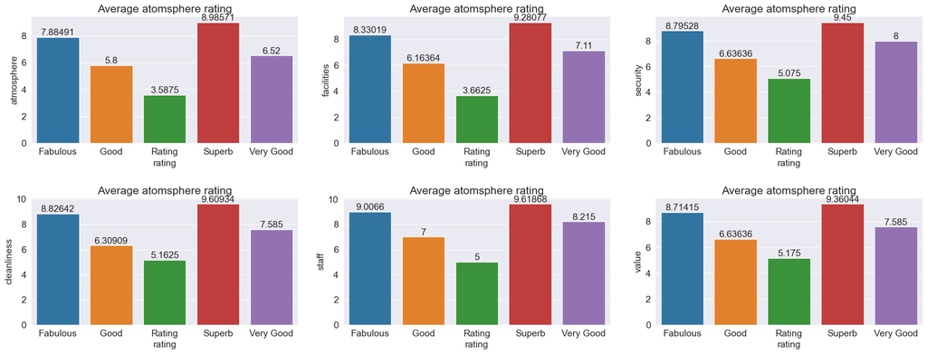

```python
fig, axes = plt.subplots(2, 3, figsize=(20, 8))

# Use the axes for plotting
axes[0,0].set_title('Average atomsphere rating')
ax0 = sns.barplot(x = avg_rating_df.index, y = avg_rating_df.atmosphere, ax = axes[0,0])
ax0.bar_label(ax0.containers[0])

axes[1,0].set_title('Average atomsphere rating')
ax1 = sns.barplot(x = avg_rating_df.index, y = avg_rating_df.cleanliness, ax = axes[1,0])
ax1.bar_label(ax1.containers[0])

axes[0,1].set_title('Average atomsphere rating')
ax2 = sns.barplot(x = avg_rating_df.index, y = avg_rating_df.facilities, ax = axes[0,1])
ax2.bar_label(ax2.containers[0])

axes[0,2].set_title('Average atomsphere rating')
ax3 = sns.barplot(x = avg_rating_df.index, y = avg_rating_df.security, ax = axes[0,2])
ax3.bar_label(ax3.containers[0])

axes[1,1].set_title('Average atomsphere rating')
ax4 = sns.barplot(x = avg_rating_df.index, y = avg_rating_df.staff, ax = axes[1,1])
ax4.bar_label(ax4.containers[0])

axes[1,2].set_title('Average atomsphere rating')
ax5 = sns.barplot(x = avg_rating_df.index, y = avg_rating_df.value, ax = axes[1,2])
ax5.bar_label(ax5.containers[0])



plt.tight_layout(pad=2);
```

I wanted to see the average scores for each rating to see where 'rating' lines up in the rating scale.

I used the plt.subplots method to create multiple graphs to visual the average scores for every category for each rating.

As we can see 'rating' as the lowest average scores across the board meaning that the 'rating' rating is the lowest rating in the dataset.

#### Q3: Which hostel has the best value of money rating?

Since the value category is a rating for the value for the money, I am curious to see what makes the hostel worth its price. What is the cost? Is the distance very close to the center of city?

```python
df_clean.nlargest(n=10, columns = ['value'])
```

|  | hostel | city | price | distance | summary | rating | atmosphere | cleanliness | facilities | location_rating | security | staff | value |
| --- | --- | --- | --- | --- | --- | --- | --- | --- | --- | --- | --- | --- | --- |
| 13 | Akihabara Hotel 3000 | Tokyo | 2200 | 8.0 | 10.0 | Superb | 10.0 | 10.0 | 10.0 | 10.0 | 10.0 | 10.0 | 10.0 |
| 30 | Beagle Tokyo Hostel & Apartments | Tokyo | 3800 | 16.1 | 9.0 | Superb | 8.0 | 10.0 | 9.0 | 8.0 | 9.0 | 9.0 | 10.0 |
| 48 | Capsule Inn Kinshichou | Tokyo | 2600 | 10.9 | 8.6 | Fabulous | 6.0 | 10.0 | 8.0 | 8.0 | 10.0 | 8.0 | 10.0 |
| 55 | Chaganjutei | Kyoto | 3300 | 14.1 | 9.6 | Superb | 10.0 | 10.0 | 9.0 | 9.0 | 9.0 | 10.0 | 10.0 |
| 58 | Colours | Kyoto | 1600 | 1.8 | 8.9 | Fabulous | 4.0 | 10.0 | 10.0 | 8.0 | 10.0 | 10.0 | 10.0 |
| 60 | Common de Hostel & Bar | Fukuoka | 2500 | 0.8 | 9.9 | Superb | 10.0 | 10.0 | 10.0 | 9.0 | 10.0 | 10.0 | 10.0 |
| 71 | Friends Kyo | Kyoto | 2200 | 1.2 | 10.0 | Superb | 10.0 | 10.0 | 10.0 | 10.0 | 10.0 | 10.0 | 10.0 |
| 77 | Goen Lounge＆Stay | Osaka | 2000 | 18.2 | 8.9 | Fabulous | 8.0 | 10.0 | 10.0 | 6.0 | 8.0 | 10.0 | 10.0 |
| 79 | Gojo Guesthouse - Annex | Kyoto | 2500 | 1.7 | 9.6 | Superb | 8.7 | 10.0 | 9.3 | 9.3 | 10.0 | 10.0 | 10.0 |
| 87 | Guest House Denchi | Tokyo | 3600 | 9.2 | 8.9 | Fabulous | 8.0 | 10.0 | 6.0 | 8.0 | 10.0 | 10.0 | 10.0 |

Using the nlargest method, I looked at the top 10 hostel's with the highest value for money.

We can see that Akihabara Hotel 3000 is at the top having a 10.0 score for every category. Something I found interesting is the hostel Colours has a 10 value rating but we can see that the atmosphere rating is very low at 4.0. I am guessing that the other scores being high rated while being the cheapest and relatively close to the center of the city brings it back to a 10.0.

I see that Friends Kyo also has 10's across the board so the top 10 here is just by index order if the value is the same which is not exactly what I was looking for.

```python
len(df_clean[df_clean['value'] == 10.0])
```

```
31
```

Using the len method, we can see that there are 31 hostels with a 10.0 for the value of money score.

#### Q4: Which hostel has the best summary score?

Since it was a bit difficult to see which hostel was considered the "best" by value, I will look at the summary score which is just the average of all the scores in every category including value.

```python
df_clean.nlargest(n=10, columns = ['summary'])
```

|  | hostel | city | price | distance | summary | rating | atmosphere | cleanliness | facilities | location_rating | security | staff | value |
| --- | --- | --- | --- | --- | --- | --- | --- | --- | --- | --- | --- | --- | --- |
| 13 | Akihabara Hotel 3000 | Tokyo | 2200 | 8.0 | 10.0 | Superb | 10.0 | 10.0 | 10.0 | 10.0 | 10.0 | 10.0 | 10.0 |
| 71 | Friends Kyo | Kyoto | 2200 | 1.2 | 10.0 | Superb | 10.0 | 10.0 | 10.0 | 10.0 | 10.0 | 10.0 | 10.0 |
| 89 | Guest House Hachi | Kyoto | 3200 | 3.2 | 10.0 | Superb | 10.0 | 10.0 | 10.0 | 10.0 | 10.0 | 10.0 | 10.0 |
| 111 | Guesthouse Morizou Female only | Osaka | 2000 | 3.7 | 10.0 | Superb | 10.0 | 10.0 | 10.0 | 10.0 | 10.0 | 10.0 | 10.0 |
| 135 | Hostel Chapter Two Tokyo | Tokyo | 2700 | 9.8 | 10.0 | Superb | 10.0 | 10.0 | 10.0 | 10.0 | 10.0 | 10.0 | 10.0 |
| 237 | Norishico Auto Guesthouse | Fukuoka | 2800 | 16.1 | 10.0 | Superb | 10.0 | 10.0 | 10.0 | 10.0 | 10.0 | 10.0 | 10.0 |
| 300 | Tabicolle Backpackers | Fukuoka | 2500 | 2.3 | 10.0 | Superb | 10.0 | 10.0 | 10.0 | 10.0 | 10.0 | 10.0 | 10.0 |
| 302 | Talbot | Kyoto | 2000 | 29.5 | 10.0 | Superb | 10.0 | 10.0 | 10.0 | 10.0 | 10.0 | 10.0 | 10.0 |
| 47 | Capsule Hotel Asahi Plaza Shinsaibashi | Osaka | 3000 | 4.0 | 9.9 | Superb | 10.0 | 10.0 | 10.0 | 10.0 | 10.0 | 10.0 | 9.0 |
| 60 | Common de Hostel & Bar | Fukuoka | 2500 | 0.8 | 9.9 | Superb | 10.0 | 10.0 | 10.0 | 9.0 | 10.0 | 10.0 | 10.0 |

#### Q5: Are the cheapest hostel's worth it?

```python
df_clean.nsmallest(n=10, columns = ['price'])
```

|  | hostel | city | price | distance | summary | rating | atmosphere | cleanliness | facilities | location_rating | security | staff | value |
| --- | --- | --- | --- | --- | --- | --- | --- | --- | --- | --- | --- | --- | --- |
| 63 | Downtown Inn Kyoto | Kyoto | 1000 | 1.4 | 9.3 | Superb | 8.9 | 9.7 | 9.7 | 9.1 | 9.1 | 8.6 | 9.7 |
| 179 | Ikidane House Namba | Osaka | 1200 | 6.5 | 9.3 | Superb | 8.9 | 9.6 | 9.7 | 8.8 | 8.9 | 9.6 | 9.6 |
| 262 | Peace House Abeno | Osaka | 1200 | 6.9 | 9.0 | Superb | 9.0 | 9.1 | 9.1 | 8.2 | 9.1 | 9.1 | 9.3 |
| 263 | Peace House Sachi | Osaka | 1200 | 6.5 | 8.6 | Fabulous | 8.8 | 8.2 | 7.9 | 8.9 | 8.4 | 9.2 | 8.8 |
| 265 | Peace House Showa | Osaka | 1200 | 6.8 | 7.5 | Very Good | 8.0 | 6.4 | 5.6 | 8.0 | 6.4 | 9.6 | 8.4 |
| 266 | Peace House Suzunami | Osaka | 1200 | 6.4 | 8.2 | Fabulous | 8.4 | 7.1 | 7.9 | 8.7 | 8.0 | 8.9 | 8.2 |
| 20 | Asakusa Hostel Toukaisou | Tokyo | 1300 | 9.3 | 8.9 | Fabulous | 7.9 | 9.4 | 8.3 | 9.5 | 9.2 | 8.9 | 9.2 |
| 141 | Hostel Ginkakuji | Kyoto | 1300 | 2.7 | 4.9 | Rating | 2.0 | 10.0 | 6.0 | 6.0 | 2.0 | 2.0 | 6.0 |
| 172 | Hotel Sun Plaza | Osaka | 1300 | 6.3 | 6.5 | Good | 6.0 | 7.3 | 6.0 | 6.7 | 6.0 | 7.3 | 6.0 |
| 264 | Peace House Sakura | Kyoto | 1300 | 1.8 | 6.3 | Good | 6.8 | 5.8 | 5.3 | 6.5 | 6.3 | 6.8 | 7.0 |

I wanted to see if the cheapest hostel's in the dataset are actually worth it.

Using the nsmallest method, we can see the top 10 cheapest hostels in Japan. Surprisingly enough, the cheapest hostel Downtown Inn Kyoto, has an overall high rating across the board, is relatively close to the center of the city and has a superb rating for only 1000 yen (less $10 usd). Something I found interesting is that the 9 out of the 10 cheapest hostel's are all located in Osaka and Kyoto which are both in the same region of Japan (Kansai).

Based on personal experience, staying in Osaka did seem cheaper than Tokyo but I am surprised not to see any Fukuoka and Hiroshima hostel's on here but maybe that is due to the low sample size for those two cities.

```python
df_clean.nlargest(n=12, columns = ['price'])
```

|  | hostel | city | price | distance | summary | rating | atmosphere | cleanliness | facilities | location_rating | security | staff | value |
| --- | --- | --- | --- | --- | --- | --- | --- | --- | --- | --- | --- | --- | --- |
| 290 | Shell Nell namba | Osaka | 1003200 | 4.8 | 8.3 | Fabulous | 6.0 | 8.0 | 9.0 | 9.0 | 9.0 | 9.0 | 8.0 |
| 317 | Tokyo Central Youth Hostel | Tokyo | 1003200 | 4.8 | 8.0 | Fabulous | 6.0 | 10.0 | 10.0 | 8.0 | 8.0 | 8.0 | 6.0 |
| 301 | Tadaima Japan Shinjuku Ryokan | Tokyo | 7600 | 2.8 | 8.4 | Fabulous | 8.0 | 9.0 | 9.0 | 8.0 | 8.0 | 9.0 | 8.0 |
| 200 | Kaneyoshi Ryokan, Namba Dotombori | Osaka | 6500 | 4.2 | 9.4 | Superb | 10.0 | 9.0 | 9.0 | 10.0 | 9.0 | 10.0 | 9.0 |
| 311 | The Millennials Shibuya | Tokyo | 6300 | 3.1 | 9.3 | Superb | 8.9 | 10.0 | 9.3 | 9.8 | 9.5 | 8.9 | 8.7 |
| 234 | Nadeshiko Hotel Shibuya (Female Only) | Tokyo | 5500 | 3.8 | 9.2 | Superb | 8.7 | 9.7 | 9.7 | 8.7 | 9.7 | 9.3 | 8.7 |
| 327 | Turn Table Hostel | Tokyo | 5400 | 3.8 | 9.6 | Superb | 9.4 | 9.9 | 9.7 | 9.7 | 9.6 | 9.6 | 9.3 |
| 333 | WIRED HOTEL Asakusa | Tokyo | 5200 | 9.7 | 9.5 | Superb | 8.9 | 10.0 | 9.9 | 9.1 | 9.7 | 9.6 | 9.5 |
| 41 | Book And Bed Tokyo Fukuoka | Fukuoka | 4300 | 0.3 | 8.6 | Fabulous | 8.0 | 10.0 | 6.0 | 10.0 | 8.0 | 10.0 | 8.0 |
| 165 | Hotel Cargo Shinsaibashi | Osaka | 4200 | 3.2 | 9.3 | Superb | 8.4 | 9.6 | 8.8 | 8.8 | 9.6 | 10.0 | 9.6 |
| 40 | Book And Bed Tokyo Asakusa | Tokyo | 4100 | 9.6 | 9.1 | Superb | 8.7 | 9.7 | 8.6 | 9.4 | 9.5 | 9.3 | 8.6 |
| 42 | Book And Bed Tokyo Ikebukuro | Tokyo | 4100 | 4.9 | 8.2 | Fabulous | 8.9 | 8.0 | 8.0 | 9.1 | 7.7 | 8.6 | 7.4 |

After looking at the cheapest hostel's, I wanted to also see if the most expensive hostel's are worth it.

Using the nlargest method, we can see the top 12 most expensive hostel's. I decided to look at the top 12 because of the two outliers.

Looking at the two outliers, we can see the rating is only a fabulous despite it's price. It is odd to see that the value is rated relatively high for Shell Nell namba despite these ratings and the price. This leads me to believe that these two prices might be a mistake in the dataset.

Aside from the outliers, it is no surprise that most of the hostel's have a superb rating because it should be expected to have high ratings in all these categories if you are paying a premium for it.

Unlike the cheapest hostel's, the majority of the most expensive hostel's are located in Tokyo which makes sense given the popularity of the city amongst tourists.

## Inferences and Conclusion

I found a lot of interesting information through transforming the dataset using the things I learned in this course. I was able to see that a lot of the hostel's in the dataset had a relatively similar price despite the distance from the center of the city. This is probably due to how efficient the Japanese train system is so distance isn't much of a factor when people choose a place to stay. We found that the average prices of the hostel's were very similar in every city (excluding outliers). Based on my findings, the value for money rating didn't prove to be very useful when trying to figure out what the "best" hostel was and the summary rating proved to be more useful. We also found that the majority of the hostel's had a rating of superb and fabulous and was able uncover what the 'rating' rating was. With all this, we can conclude that hostel's in Japan are overall well maintained and affordable in Tokyo, Osaka, Kyoto, Fukuoka, and Hiroshima.

## References and Future Work

Something I would be interested in is hostels in other cities in Japan especially Hokkaido which is another hot spot for tourists. Another thing that would be interesting to see is an updated version of the dataset as this dataset is a few years old so I would like to see the effects of COVID-19 and see if there are any drastic changes. Something I would improve on is making sure there aren't any errors in the dataset because I am not sold on the two outlier hostel's being accurate in price as they seem too ridiculous to be real.

Link to the dataset: https://www.kaggle.com/datasets/koki25ando/hostel-world-dataset

Pandas Documentation: https://pandas.pydata.org/docs/user_guide/index.html#user-guide

Putting the value over bar plots: https://stackoverflow.com/questions/43214978/how-to-display-custom-values-on-a-bar-plot